# R Notebook

### Introduction

We know that GWAS in aibs is unaffected by population stratification. We were interested in testing whether ascertaining SNPs in a GWAS of unrelated individuals and then re-estimating effect sizes in sibs results in residual stratification in the PRS. To test this, I constructed sibling haplotypes fro the ‘test set’ genotypes either by randomly pairing haplotypes in the population or pairing them within each deme (assortative) and then carried out a GWAS using the difference in the phenotype of sibs as the response and the difference in genotype as the predictor. The simulated phenotypes were constructed either with smooth (latitude) or sharp environmental effects (ran random and smooth (longitude) environment also but results not shown here). Then, I constructed PRS in an independent (originally training set) using sib effect sizes for variants ascertained in two different ways:

1. lead SNPs in the sibs
2. lead SNPs from the unrelated GWAS

The hypothesis is that the PRS generated from effect sizes from (2) would still capture some residual population stratification because these SNPs are likely to be more structured.

### Implementation

```r
library(ggplot2)
library(dplyr)
library(data.table)
library(rprojroot)
library(patchwork)
#specify root of the directory
F = is_rstudio_project$make_fix_file()
```

```r
colnames(gvalues.train) = colnames(gvalues.test) = c("rep","IID","dosage","gvalue")
```

```
Error in colnames(gvalues.train) = colnames(gvalues.test) = c("rep", "IID",  :
  object 'gvalues.train' not found
```

```r
#load the prs for smooth effect
sm.gwas = fread(F("gwas/complex_dem/test/prs/complexdem_prs_smooth.all.nc.sscore.gz"))
sm.asc = fread(F("gwas/complex_dem/train/prs4msibs_asc/complexdem_prs_psmooth.massort.e1_20.asc.nc.sscore"))
sm.unasc = fread(F("gwas/complex_dem/train/prs/complexdem_prs_psmooth.massort.e1_20.all.sscore"))
#load prs for sharp effect
shp.gwas = fread(F("gwas/complex_dem/test/prs/complexdem_prs_sharp.all.nc.sscore.gz"))
shp.asc = fread(F("gwas/complex_dem/train/prs4msibs_asc/complexdem_prs_psharp.massort.e1_20.asc.nc.sscore"))
shp.unasc = fread(F("gwas/complex_dem/train/prs/complexdem_prs_psharp.massort.e1_20.all.sscore"))
colnames(sm.gwas) = colnames(shp.gwas) = c("rep","IID","dosage","pcs0","cm","re","cmre")
colnames(sm.asc) = colnames(shp.asc) = c("rep","IID","dosage","pcs0","cm","re")
colnames(shp.unasc) = colnames(sm.unasc) = c("rep","IID","dosage","causal","causal_p","lead_snp")
sm.gwas = sm.gwas %>%
  select(rep,IID,pcs0)
shp.gwas = shp.gwas %>%
  select(rep,IID,pcs0)
sm.asc = sm.asc%>%
  select(rep,IID,pcs0)
shp.asc = shp.asc%>%
  select(rep,IID,pcs0)
sm.unasc = sm.unasc%>%
  select(rep,IID,lead_snp)
shp.unasc = shp.unasc%>%
  select(rep,IID,lead_snp)
#rbind all so we can plot together
sm.asc$phenotype = sm.unasc$phenotype = sm.gwas$phenotype = "Smooth"
shp.asc$phenotype =  shp.unasc$phenotype = shp.gwas$phenotype = "Sharp"
sm.gwas$ascertainment = shp.gwas$ascertainment = "gwas_only"
sm.asc$ascertainment = shp.asc$ascertainment = "gwas_sib"
sm.unasc$ascertainment = shp.unasc$ascertainment = "sib_only"
colnames(sm.asc)[3] = colnames(shp.asc)[3] = colnames(sm.unasc)[3] = colnames(shp.unasc)[3] = colnames(sm.gwas)[3]  = colnames(shp.gwas)[3] = "prs"
sm = rbind(sm.gwas,sm.asc,sm.unasc)
shp = rbind(shp.gwas,shp.asc,shp.unasc)
#load pop file which contains info on each individual's x,y coordinates and add this info
pop.train = fread(F("gwas/complex_dem/genos_complex_l1e7_ss500_m0.07.train.pop"))
pop.test = fread(F("gwas/complex_dem/genos_complex_l1e7_ss500_m0.07.test.pop"))
pop = rbind(pop.train,pop.test)
sm = merge(sm, pop, by="IID")
shp = merge(shp, pop,by="IID")
#add simulated genetic values
sm = merge(sm, gvalues, by=c("rep","IID"))
shp  = merge(shp, gvalues, by=c("rep","IID"))
#remove variation due to simulated genetic value
#also calculate the correlation between prs and longitude/latitude
prs_sm = sm%>%
  group_by(rep,ascertainment,phenotype)%>%
  mutate(prs = resid(lm(prs~gvalue)))%>%
  ungroup()
prs_shp = shp%>%
  group_by(rep,ascertainment,phenotype)%>%
  mutate(prs = resid(lm(prs~gvalue)))%>%
  ungroup()
#average prs per deme
prs_sm.mean = prs_sm%>%
  group_by(rep,phenotype,ascertainment)%>%
  mutate(prs = prs - mean(prs) )%>%
  ungroup()%>%
  group_by(longitude,latitude,ascertainment)%>%
  summarize(prs=mean(prs))%>%
  ungroup()
prs_shp.mean = prs_shp%>%
  group_by(rep,phenotype,ascertainment)%>%
  mutate(prs = prs - mean(prs) )%>%
  ungroup()%>%
  group_by(longitude,latitude,ascertainment)%>%
  summarize(prs=mean(prs))%>%
  ungroup()
#generate the plots
labels_prs=c(
  gwas_only="Standard GWAS",
  gwas_sib="Standard GWAS+\n sib re-estimation",
  sib_only="sib-based GWAS"
)
```

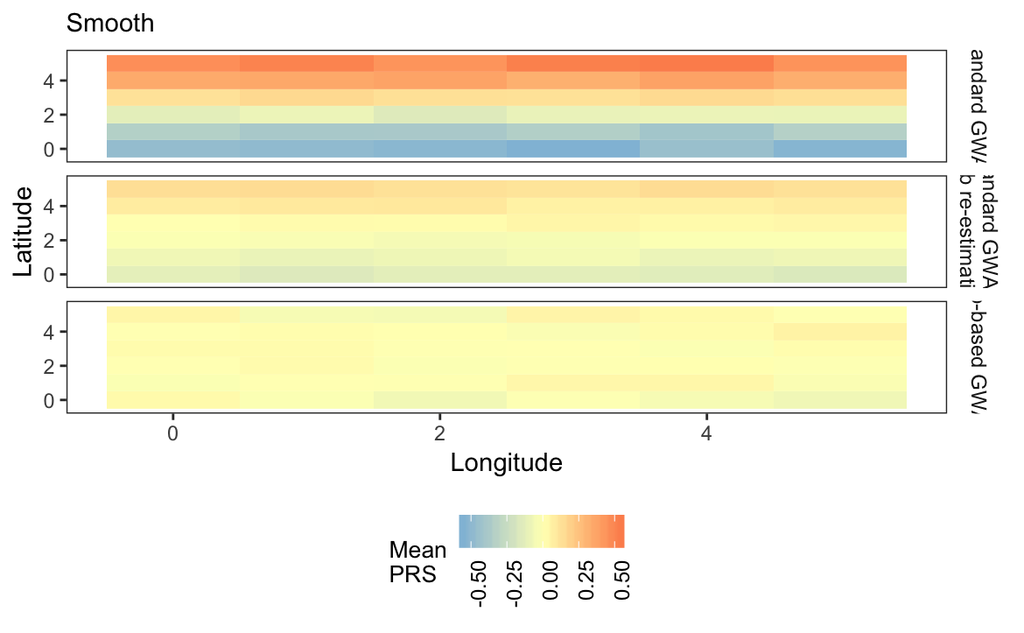

```r
#plot for smooth effect
prs_midpoint_sm = prs_sm.mean%>%
  pull(prs)%>%
  mean()
plt_smooth = ggplot(prs_sm.mean,
                    aes(longitude,latitude,fill=prs))+
  geom_tile()+
  facet_grid(ascertainment~.,
             labeller=as_labeller(labels_prs))+
  theme_bw()+
  scale_fill_gradient2(high = "#fc8d59",
                         mid = "#ffffbf",
                         low = "#91bfdb",
                         midpoint = prs_midpoint_sm)+
    labs(x="Longitude", y="Latitude", title="Smooth", fill="Mean\nPRS")+
    theme(plot.title=element_text(hjust=0,size=11),
          strip.text = element_text(size=9),
          panel.grid = element_blank(),
          legend.text = element_text(size=9,angle=90,hjust=1),
          legend.title = element_text(size=10),
          legend.key.size = unit(5, "mm"),
          legend.position="bottom",
          legend.background = element_blank(),
          plot.background = element_blank(),
          strip.background = element_blank())
plt_smooth
```

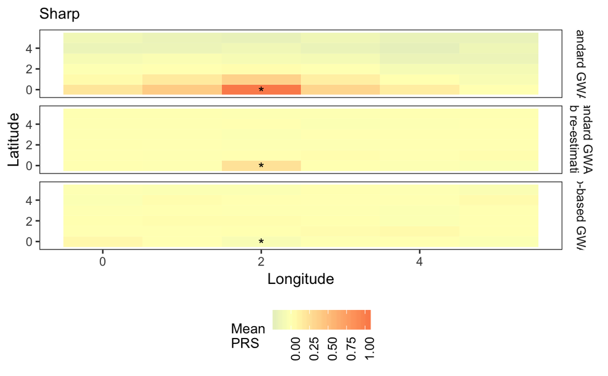

```r
#plot for sharp effect
prs_midpoint_shp = prs_shp.mean%>%
  pull(prs)%>%
  mean()
plt_sharp = ggplot(prs_shp.mean,
                    aes(longitude,latitude,fill=prs))+
  geom_tile()+
  facet_grid(ascertainment~.,
             labeller=as_labeller(labels_prs))+
  annotate(geom="text",x=2,y=0,label="*",vjust=0.7)+
  theme_bw()+
  scale_fill_gradient2(high = "#fc8d59",
                         mid = "#ffffbf",
                         low = "#91bfdb",
                         midpoint = prs_midpoint_sm)+
    labs(x="Longitude", y="Latitude", title="Sharp", fill="Mean\nPRS")+
    theme(plot.title=element_text(hjust=0,size=11),
          strip.text = element_text(size=9),
          panel.grid = element_blank(),
          legend.text = element_text(size=9,angle=90,hjust=1),
          legend.title = element_text(size=10),
          legend.key.size = unit(5, "mm"),
          legend.position="bottom",
          legend.background = element_blank(),
          plot.background = element_blank(),
          strip.background = element_blank())
plt_sharp
```

Join the two plots

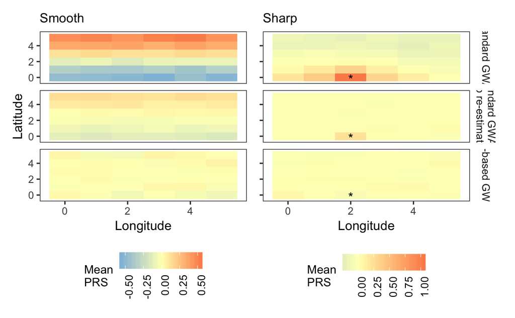

Plot the correlation between latitude and the smooth PRS

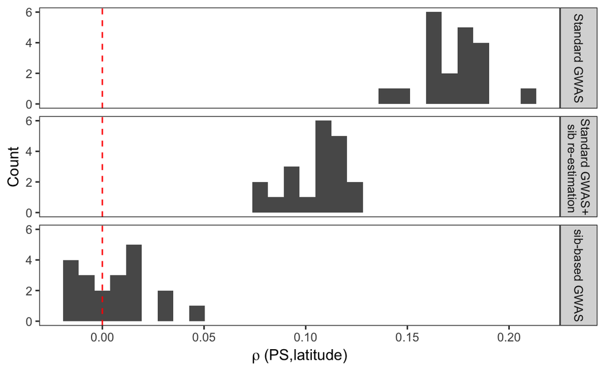

Make a combined plot

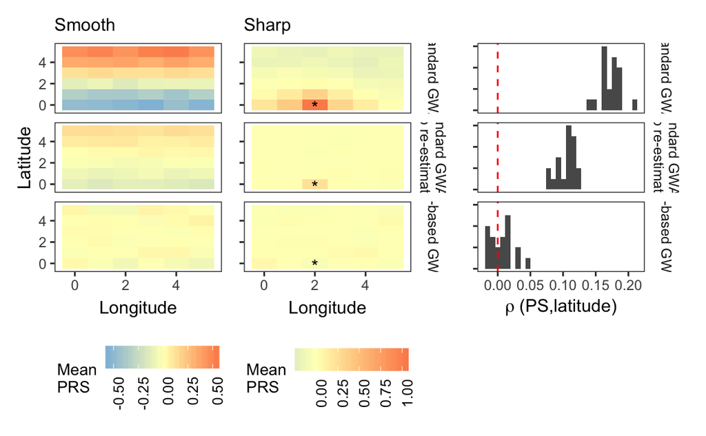